# Exploration of Stanford ‘How Couples Meet and Stay Together (HCMST)’ Dataset (ICPSR 30103)

### K-means Clustering

Using the variables we’ve found to be predictive in our regression model, let’s use a K-means clustering algorithm to define two clusters. The cases within each cluster will be relatively similar in Age + Income + Married + SameSexCouple + RelationshipYears + Cohabitating + MetByNeighbors + MetByChurch + MetByBar + MetByPrivateParty + MetByOther + RelationshipQuality. The cases that are most dissimilar will be in different clusters.

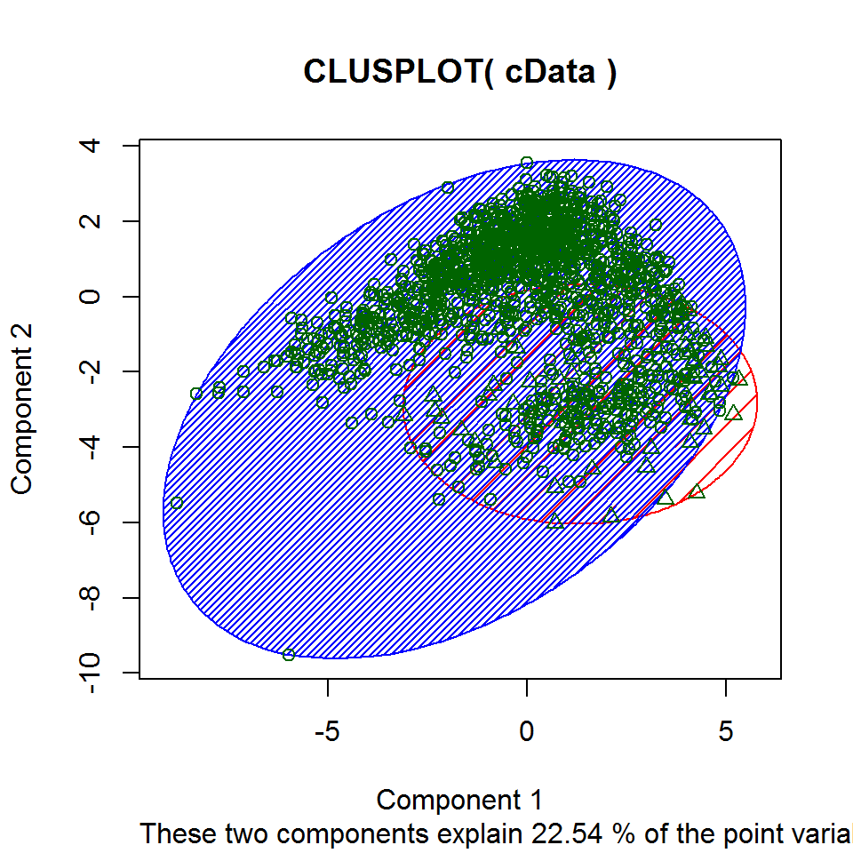

Now lets create a scatterplot of all couples with their cluster membership (1 or 2) vs. the StillTogether outcome.

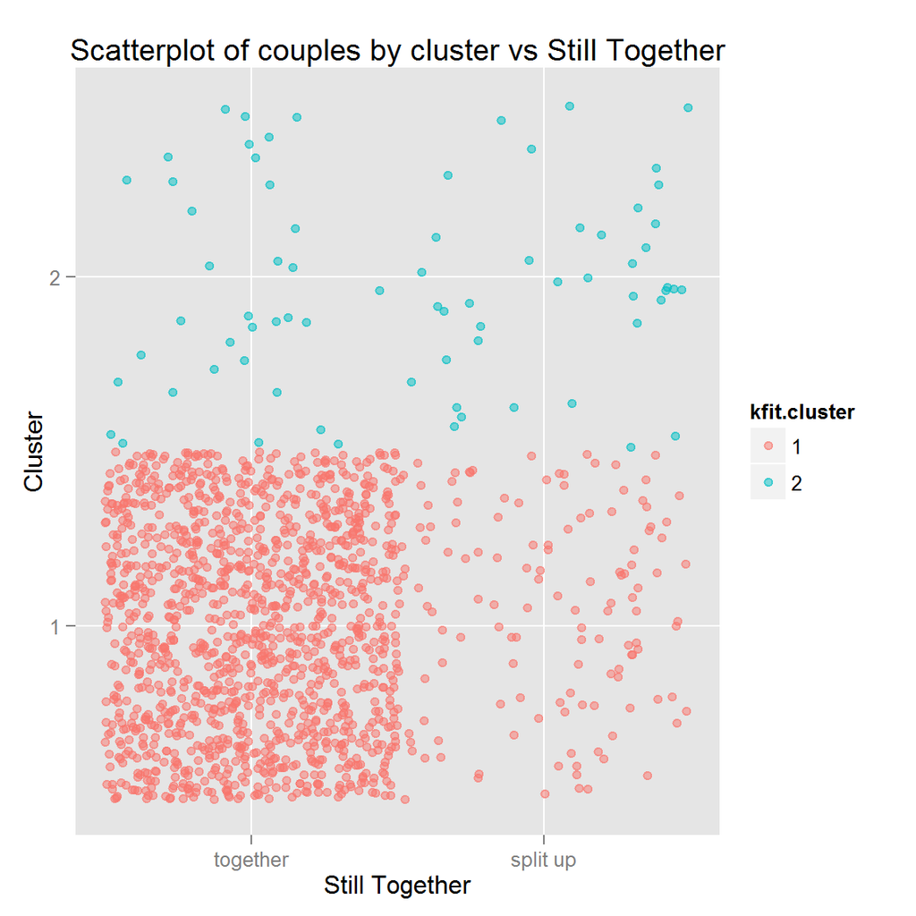

We see that cluster membership is very influential on the StillTogether variable. Most couples in cluster 1 are still together. Couples in cluster 2 seem to fairly evenly distributed between together and not together.

# Multivariate Analysis

### Talk about some of the relationships you observed in this part of the investigation. Were there features that strengthened each other in terms of looking at your feature(s) of interest?

The correlation matrix indicates some of the correlated features, such as between the subject’s age and length of relationship. Another example is GLB status of subject and couple’s same sex status. Most of these correlations make intuitive sense and were not surprising

### Were there any interesting or surprising interactions between features?

I found all of the observations to be interesting, but none particularly surprising.

### OPTIONAL: Did you create any models with your dataset? Discuss the strengths and limitations of your model.

I constructed a binomial logistic regression model with StillTogether as the dependent variable. I started with all features (aside from CaseID) as the potential independent variables. I used stepwise AIC optimization to find the optimum model for this data set. The following features were found to provide the best model explaining variability of StillTogether: Age, Relationship Quality, Income, Parental Approval, Relationship Years, Cohabitatation Years, Married, Cohabitating, Same Sex Couple, and how the couple met (5 variables). For this set of data, these attributes predicted whether or not the couple was still together with 87% accuracy.

To help confirm the model, I performed K-means clustering on the couples using the above set of attributes. I created two clusters based upon combined similarity of Age, Relationship Quality, Income, Parental Approval, Relationship Years, Cohabitatation Years, Married, Cohabitating, Same Sex Couple, and how the couple met.

# Final Plots and Summary

### Plot One

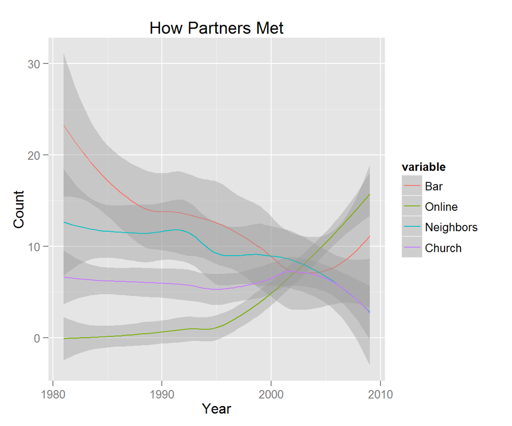

### Plot Two

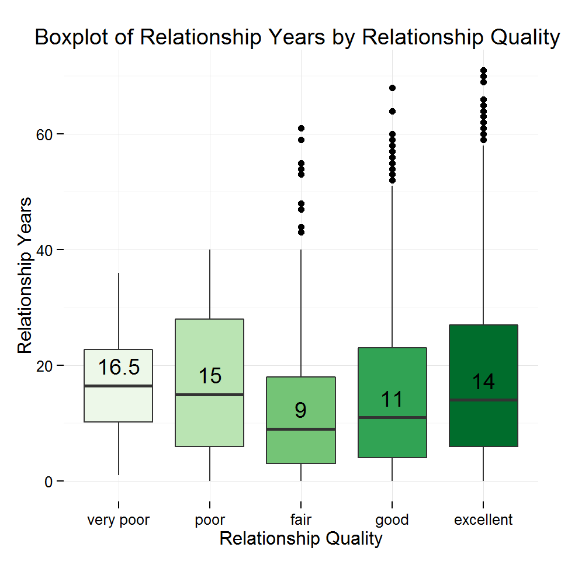

### Plot Three

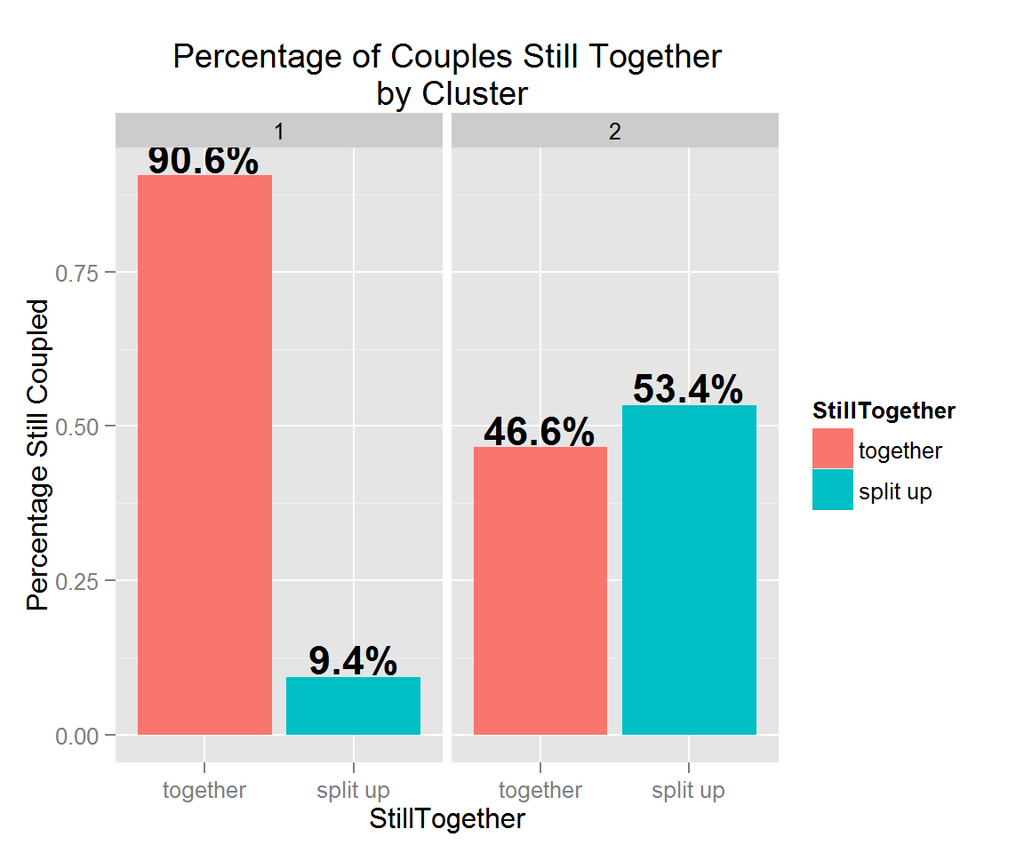

### Description Three

This is a plot of the StillTogether outcome for our two clusters of couples. I created two distinct clusters based upon combined similarity of predictive features (Age, Relationship Quality, Income, Parental Approval, Relationship Years, Cohabitatation Years, Married, Cohabitating, Same Sex Couple, and how the couple met). We see from the two plots that one of the clusters is much more likely to stay together than the other. This helps validate that these factors are indeed predictive of relationship viability.

# Reflection

This was an interesting data set and I enjoyed working with it. There were over 400 features initially, so I knew that I would need to narrow down the feature set in order to make the scope of this project manageable. I chose demographic features that seemed interesting, and also reviewed (skimmed) other works in the social science domain to help with feature selection. Tidying the dataset and appropriately labeling the categorical values was a time-consuming, but essential, step in the analysis process. As this was the first time I’ve conducted a binomial logistic regression, rather than a generalized linear model, interpreting some of the results, such as the residual plots, was a challenge. If I were to expand my research on this data, I would be interested in 1.) pulling in more of the 400+ features for examination, and 2.) exploring some different methods of predictive model creation, such as random forest and related classification algorithms. I would likely also partition the data into training and test sets to help validate the model.

# Citation

Rosenfeld, Michael J., Reuben J. Thomas, and Maja Falcon. How Couples Meet and Stay Together (HCMST), Wave 1 2009, Wave 2 2010, Wave 3 2011, Wave 4 2013, United States. ICPSR30103-v7. Ann Arbor, MI: Inter-university Consortium for Political and Social Research [distributor], 2014-09-02. http://doi.org/10.3886/ICPSR30103.v7 Persistent URL: http://doi.org/10.3886/ICPSR30103.v7